# MEDISIS Fishing Effort Map

# Check the plotting methods

```r
cols <- c("#003366" = str_wrap("Seasonal Offshore Extensions Applies to Gears: OTB, OTT, GNS, and LLS Seasonally (Oct-Dec) or allYear", 28),
          "#b2182b" = str_wrap("Offshore Permanent Closures Applies to Gears: OTB, OTT, GNS, LLS allYear", 28),
          "#FF33FF" = str_wrap("90-100 Isobaths Closures Applies to Gears: OTB and OTT Seasonally (Sept-Apr) or allYear", 28),
          "#614B00" = str_wrap("Northward Expansion of FRA Applies to Gears: OTB and OTT Seasonally (Nov-Apr) or allYear", 28))

cols2 <- ("#614B00" = str_wrap("Original Fishing Restricted Area [FRA] Boundaries Applies to Gears: OTB and OTT allYear", 28))

GoL.map <- ggplot() +
  geom_sf(data = continental_sf,
          aes(fill = "#26abff"),
          alpha = 0.3) +
  geom_sf(data = canyon_sf,
          aes(fill = "#c51b7d"),
          alpha = 0.3) +
  geom_sf(data = grid,
          color = "grey") +
  geom_sf(data = zone_90_100_simplified,
          aes(color = "#FF33FF"),
          fill = "transparent",
          linewidth = 0.5) +
  geom_sf_pattern(data = FRA,
                  aes(pattern_fill = "#614B00"),
                  pattern_fill2 = "transparent",
                  pattern_colour = "transparent",
                  color = "#614B00",
                  fill = "transparent",
                  pattern_aspect_ratio = 1.8,
                  linewidth = 0.5,
                  pattern_spacing = 0.01) +
  geom_sf(data = NewFRA_regulation,
          aes(color = "#614B00"),
          fill = "transparent",
          linewidth = 0.5) +
  geom_sf(data = Offshore_closure_seasonal,
          aes(color = "#003366"),
          fill = "transparent",
          linewidth = 0.25) +
  geom_sf(data = Offshore_permanent_spdf,
                  aes(color = "#b2182b"),
                  fill = "transparent",
                  linewidth = 0.5) +
  scale_fill_identity(name = "Population Zones",
                      labels = c("#26abff" = str_wrap("Continental Shelf", 28),
                                 "#c51b7d" = str_wrap("Interface of The Continental Shelf Break and Submarine Canyon Heads", 28)),
                      guide = guide_legend("fill")) +
  scale_color_identity(name = "Closure Measures",
                       labels = cols,
                       guide = guide_legend("color")) +
  scale_pattern_fill_identity(name = element_blank(),
                              labels = cols2,
                              guide = guide_legend("pattern_fill"))+
  guides(fill = guide_legend(override.aes = list(alpha=0.3)),
         color = guide_legend(order = 1),
         pattern_fill = guide_legend(order = 2)) +
  geom_sf(data = GDL_crop,
          color = "#ae8f60",
          size = 0.7,
          fill = "#E1C699") +
  geom_sf(data = GPV.wgs84, size = 1) +
  geom_sf_text(data = GPV.wgs84,
               aes(label = Abbreviation),
               size = 3.5,
               color = "black",
               nudge_x = -0.02,
               nudge_y = 0.04) +
  geom_sf(data = CST.wgs84, size = 1) +
  geom_sf_text(data = CST.wgs84,
               aes(label = paste0(Name, " (", Abbreviation, ")", sep = '')),
               size = 3.5,
               color = "black",
               nudge_x = -0.18,
               nudge_y = 0.04) +
  geom_sf(data = XST.wgs84, size = 1) +
  geom_sf_text(data = XST.wgs84,
               aes(label = paste0(Name, " (", Abbreviation, ")", sep = '')),
               size = 3.5,
               color = "black",
               nudge_x = -0.10,
               nudge_y = 0.04) +
  geom_sf(data = GST.wgs84, size = 1) +
  geom_sf_text(data = GST.wgs84,
               aes(label = paste0(Name, " (", Abbreviation, ")", sep = '')),
               size = 3.5,
               color = "black",
               nudge_x = -0.01,
               nudge_y = 0.04) +
  geom_sf(data = CMT.wgs84, size = 1) +
  geom_sf_text(data = CMT.wgs84,
               aes(label = paste0(Name, " (", Abbreviation, ")", sep = '')),
               size = 3.5,
               color = "black",
               nudge_x = 0.05,
               nudge_y = 0.04) +
  geom_sf(data = XMA.wgs84, size = 1) +
  geom_sf_text(data = XMA.wgs84 ,
               aes(label = paste0(Name, " (", Abbreviation, ")", sep = '')),
               size = 3.5,
               color = "black",
               nudge_x = 0.20,
               nudge_y = 0.04) +
  annotation_scale(location = "br",
                   pad_x = unit(0.85, "cm"),
                   pad_y = unit(0.5, "cm"),
                   text_cex = 1,
                   tick_height = 0.9)+
  annotation_north_arrow(location = "tl",
                         which_north = "true",
                         height = unit(1, "cm"),
                         width = unit(1, "cm"),
                         pad_x = unit(1.25, "cm"),
                         pad_y = unit(0.75, "cm")) +
  theme_bw() +
  text_theme +
  theme(legend.title = element_blank(), legend.text = element_text(size = 12),
        legend.margin = margin(t=-1,r=0, l=0, b=-1,'cm'),
        legend.spacing = unit(2, 'cm'),
        legend.position="left", legend.box = "vertical",
        legend.key.height = unit(1.52, 'cm'), legend.key.width = unit(1.5, 'cm'))

GoL.map
```

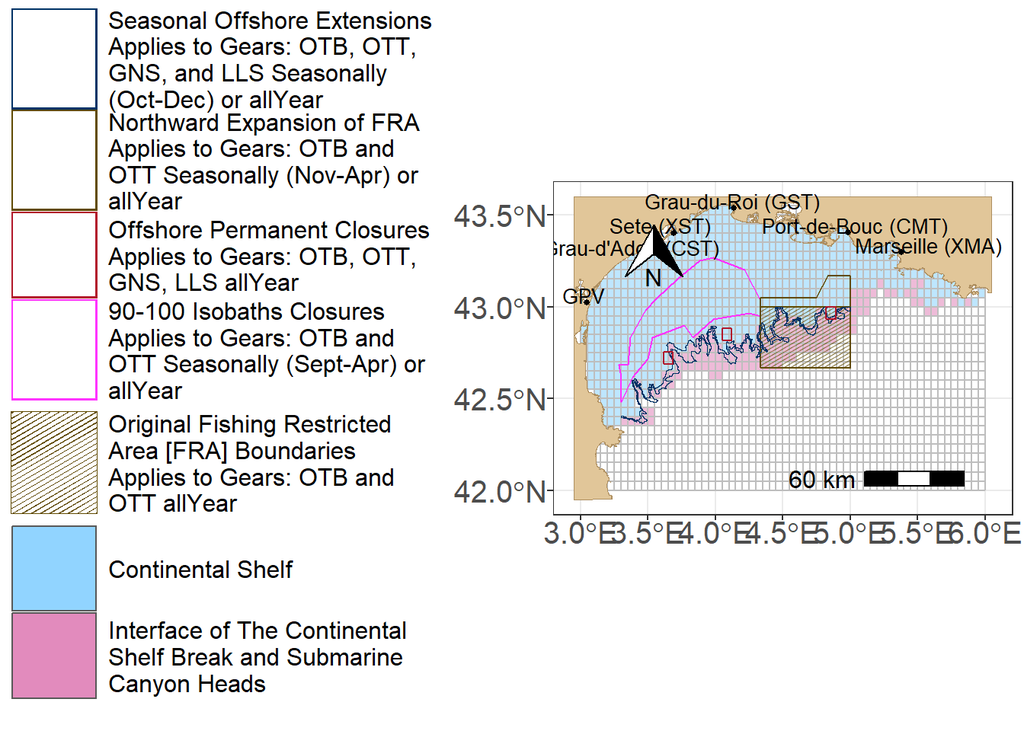

[figure not shown]

# Assign cells population defintions

We know that some cells do not have a corresponding spatial closure or fish population zone. This will not effect the model outcome as discussed above. But as information becomes available, these need to be updated so that they can be included in the effort cell computations.

```r
# Apply the fish population vector column based on existing cells
ZonesPLUS.unique.testleft.region1 <- subset(ZonesPLUS.unique.testleft, zone.y == "ContinentalShelf")

names(ZonesPLUS.unique.testleft.region1)[16] <- "Pop_Region"

dim(ZonesPLUS.unique.testleft.region1)
# [1] 8288640  16

dim(distinct(ZonesPLUS.unique.testleft.region1))
# [1] 8288640  16

# Store the cells corresponding to the Continental Plateau cells in a vector
Continental_cells <- as.vector(ZonesPLUS.unique.testleft.region1$cell)

length(Continental_cells)
# [1] 8288640

write.csv(Continental_cells, file = paste(path, 'Data/Continental_cells.csv', sep = ""))

# Apply the fish population vector column based on existing cells
ZonesPLUS.unique.testleft.region2 <- subset(ZonesPLUS.unique.testleft, zone.y == "ContinentalSlope")

names(ZonesPLUS.unique.testleft.region2)[16] <- "Pop_Region"

dim(ZonesPLUS.unique.testleft.region2)
# [1] 746880  16

dim(distinct(ZonesPLUS.unique.testleft.region2))
# [1] 746880  16

# Store the cells corresponding to the Canyon Area cells in a vector
Canyon_cells <- as.vector(ZonesPLUS.unique.testleft.region2$cell)

length(Canyon_cells)
# [1] 746880

write.csv(Canyon_cells, file = paste(path, 'Data/Canyon_cells.csv', sep = ""))

# Extract all other zones from the data frame
ZonesPLUS.unique.testleft.region3 <- subset(ZonesPLUS.unique.testleft, !zone.y %in% Pop_Region)

dim(ZonesPLUS.unique.testleft.region3)
# [1] 3897600  16

dim(distinct(ZonesPLUS.unique.testleft.region3))
# [1] 3897600  16

# Combine both Canyon and Continental Plateau data frames
ZonesPLUS.unique.testleft.region4 <- rbind(ZonesPLUS.unique.testleft.region1, ZonesPLUS.unique.testleft.region2)

dim(ZonesPLUS.unique.testleft.region4)
# [1] 9035520  16

# Combine the fish population data frame with the remaining values data frame
ZonesPLUS1 <- left_join(ZonesPLUS.unique.testleft.region3, ZonesPLUS.unique.testleft.region4, by = c("cell", "longitude", "latitude", "YEAR", "MONTH", "METIER", "simu", "InitialAbundance", "Recruitment", "Connectivity", "Scenarios", "SceName", "Nominal_Effort", "step"))

dim(ZonesPLUS1)
#v[1] 3897600  18
```

# Create a table of cell zone definitions to update in the future model

Create a table of cell definitions, with metier and zone id so that they can be more easily worked out for the next model version.

```r
# First, remove all NA values (these do not affect the data)
ZonesPLUS1.1 <- na.omit(ZonesPLUS1)

# Second, extract all values where NA's are present
ZonesPLUS1.2 <- ZonesPLUS1[is.na(ZonesPLUS1$zone.y),]

# Isolate all values where there are no fish population zones
ZonesPLUS1.3 <- ZonesPLUS1.2[is.na(ZonesPLUS1.2$Pop_Region),]

dim(ZonesPLUS1.3)
# [1] 136320  18

# Check that there are no values that were missed in the previous step when grouping cells by zone
ZonesPLUS1.3.CANYON.TEST <- subset(ZonesPLUS1.3, cell %in% Canyon_cells)

# 0 entries (method works)
dim(ZonesPLUS1.3.CANYON.TEST)
# [1]  0 18

# Repeat the same procedure for the other population zone
ZonesPLUS1.3.CONTINENTAL.TEST <- subset(ZonesPLUS1.3, cell %in% Continental_cells)

# 0 entries (method works)
dim(ZonesPLUS1.3.CONTINENTAL.TEST)
# [1]  0 18

# After verifying that these zone cell definitions truly are undefined, find all unique values
ZonesPLUS1.3.DISTINCT <- distinct(ZonesPLUS1.3)

dim(ZonesPLUS1.3.DISTINCT)
# [1] 136320  18

unique(ZonesPLUS1.3.DISTINCT$cell)
unique(ZonesPLUS1.3.DISTINCT$METIER)

# Create a data table for the undefined values and export (already done)
write.csv(ZonesPLUS1.3.DISTINCT, paste(path, "Data/Zones_without_popDefs.DISTINCT.csv",
                                       sep = ""))

# check separation (works)
ZonesPLUS1.3.DISTINCT.test <- read.csv(paste(path,
                                             "Data/Zones_without_popDefs.DISTINCT.csv",
                                             sep = ""))

unique(ZonesPLUS1.3.DISTINCT$METIER)

effort_check <- subset(ZonesPLUS1.3.DISTINCT, METIER == "OTB_GPV_24-40")

dim(effort_check)
# [1] 3840  18

unique(effort_check$Scenarios)

unique(effort_check$cell)

effort_check2 <- subset(ZonesPLUS1.3.DISTINCT, METIER == "OTB_XST_24-40")

dim(effort_check2)
# [1] 1920  18

unique(effort_check2$Scenarios)

unique(effort_check2$cell)

effort_check3 <- subset(ZonesPLUS1.3.DISTINCT, METIER == "OTB_GST_18-24")

dim(effort_check3)
# [1] 1920  18

unique(effort_check3$Scenarios)

unique(effort_check3$cell)

effort_check4 <- subset(ZonesPLUS1.3.DISTINCT, METIER == "OTT_XST_24-40")

dim(effort_check4)
# [1] 1920  18

unique(effort_check4$Scenarios)

unique(effort_check4$cell)

effort_check5 <-  subset(ZonesPLUS1.3.DISTINCT, METIER == "OTM_XST_24-40")

dim(effort_check5)
# [1] 1920   18

unique(effort_check5$Scenarios)

unique(effort_check5$cell)
```

# Appendix B, Figs. B1 -B23 & Appendix C., Figs. C1 - C.2

Create zone definition maps. For métier, population and closure zones create maps.

```r
# Type "T" if made, "F" is not
zone_def_plots  = F

if (zone_def_plots == FALSE){

for (z in unique(ZonesPLUS2.melt2$zone)){
  zone_subset <- ZonesPLUS2.melt2[ZonesPLUS2.melt2$zone == z,]
  print(z)

  zone_subset <- zone_subset %>%
    distinct(cell, .keep_all = T)

  zone_subset$longitude <- zone_subset$longitude + 0.025
  zone_subset$latitude <- zone_subset$latitude + 0.025

  # Create a sf object
  zone_subset_wgs84 <- st_as_sf(zone_subset,
                                coords = c("longitude", "latitude"),
                                crs = st_crs(4326))

  # Create gridded polygon values
  zone_subset_stars <- st_rasterize(zone_subset_wgs84,
                                    st_as_stars(st_bbox(grid),
                                                values = NA_real_,
                                                dx = 0.05,
                                                dy = 0.05))

  zone_subset_sf <- st_as_sf(zone_subset_stars)

  p.z <- ggplot() +
    geom_sf(data = zone_subset_sf,
            fill = alpha("#8cd3ff"),
            size = 0.3,
            alpha=0.5) +
    geom_sf(data = grid,
            color = "grey") +
    geom_sf(data = zone_90_100_simplified,
            aes(color = "#FF33FF"),
            fill = "transparent",
            linewidth = 0.5) +
    geom_sf_pattern(data = FRA,
                    aes(pattern_fill = "#614B00"),
                    pattern_fill2 = "transparent",
                    pattern_colour = "transparent",
                    color = "#614B00",
                    fill = "transparent",
                    pattern_aspect_ratio = 1.8,
                    linewidth = 0.5,
                    pattern_spacing = 0.01) +
    geom_sf(data = NewFRA_regulation,
            aes(color = "#614B00"),
            fill = "transparent",
            linewidth = 0.5) +
    geom_sf(data = Offshore_closure_seasonal,
            aes(color = "#003366"),
            fill = "transparent",
            linewidth = 0.25) +
    geom_sf(data = Offshore_permanent_spdf,
            aes(color = "#b2182b"),
            fill = "transparent",
            linewidth = 0.5) +
    scale_color_identity(name = "Closure Measures",
                         labels = cols,
                         guide = guide_legend("color")) +
    scale_pattern_fill_identity(name = element_blank(),
                                labels = cols2,
                                guide = guide_legend("pattern_fill")) +
    guides(color = guide_legend(order = 1),
           pattern_fill = guide_legend(order = 2)) +
    geom_sf(data = GDL_crop,
            color = "#ae8f60",
            size = 0.7,
            fill = "#E1C699") +
    geom_sf(data = GPV.wgs84, size = 1) +
    geom_sf_text(data = GPV.wgs84,
                 aes(label = Abbreviation),
                 size = 3.5,
                 color = "black",
                 nudge_x = -0.02,
                 nudge_y = 0.04) +
    geom_sf(data = CST.wgs84, size = 1) +
    geom_sf_text(data = CST.wgs84,
                 aes(label = paste0(Name, " (", Abbreviation, ")", sep = '')),
                 size = 3.5,
                 color = "black",
                 nudge_x = -0.18,
                 nudge_y = 0.04) +
    geom_sf(data = XST.wgs84, size = 1) +
    geom_sf_text(data = XST.wgs84,
                 aes(label = paste0(Name, " (", Abbreviation, ")", sep = '')),
                 size = 3.5,
                 color = "black",
                 nudge_x = -0.10,
                 nudge_y = 0.04) +
    geom_sf(data = GST.wgs84, size = 1) +
    geom_sf_text(data = GST.wgs84,
                 aes(label = paste0(Name, " (", Abbreviation, ")", sep = '')),
                 size = 3.5,
                 color = "black",
                 nudge_x = -0.01,
                 nudge_y = 0.04) +
    geom_sf(data = CMT.wgs84, size = 1) +
    geom_sf_text(data = CMT.wgs84,
                 aes(label = paste0(Name, " (", Abbreviation, ")", sep = '')),
                 size = 3.5,
                 color = "black",
                 nudge_x = 0.05,
                 nudge_y = 0.04) +
    geom_sf(data = XMA.wgs84, size = 1) +
    geom_sf_text(data = XMA.wgs84,
                 aes(label = paste0(Name, " (", Abbreviation, ")", sep = '')),
                 size = 3.5,
                 color = "black",
                 nudge_x = 0.20,
                 nudge_y = 0.04) +
    annotation_scale(location = "br",
                     pad_x = unit(0.85, "cm"),
                     pad_y = unit(0.5, "cm"),
                     text_cex = 1,
                     tick_height = 0.9)+
    annotation_north_arrow(location = "tl",
                           which_north = "true",
                           height = unit(1, "cm"),
                           width = unit(1, "cm"),
                           pad_x = unit(1.25, "cm"),
                           pad_y = unit(0.75, "cm")) +
    theme_bw() +
    theme(legend.title = element_blank(), legend.text = element_text(size = 12),
          legend.margin = unit(0.00, 'cm'), legend.spacing = unit(2, 'cm'),
          legend.position="left", legend.box = "vertical",
          legend.key.height = unit(1.52, 'cm'), legend.key.width = unit(1.5, 'cm')) +
    text_theme

    file.name <- paste0(z, "_Zone_Definitions", sep = '')

    ggsave2(filename=paste(file.name,".pdf",sep=''),plot=p.z,device="pdf",
            path=paste(path, "Figures/", sep=""), dpi=1200, width = 29, height=15,
            unit="cm", limitsize = FALSE)
    }

  }
```

# Adjust effort to cells

You need to subtract out closure area from the metier used in each scenario separately !!!

## Setup conditional formatting

In this step, we identify the number zone closure cells per scenario by the Metier / Month level and we also use the same conditions to simultaneously redefine effort for these cells to zero. This is only for visualisation purposes as the computations are done automatically in-fish

```r
combined_fishing_effort_closure2 <- subset(combined_fishing_effort_closure.final,
                                           YEAR == 2024)
colnames(combined_fishing_effort_closure2)

EffortMetierZonesPLUS.correct <- data.table()

# Type "T" if made, "F" is not
EffortMetierZonesPLUS.correct.made = T

if (EffortMetierZonesPLUS.correct.made == FALSE){

for (m in unique(combined_fishing_effort_closure2$METIER)){
  metier_subset <-
    combined_fishing_effort_closure2[combined_fishing_effort_closure2$METIER == m, ]
  print(m)

  for (s in unique(metier_subset$Scenarios)){
    metier_scen_subset <- metier_subset[metier_subset$Scenarios == s,]
    print(s)

      for (i in unique(metier_subset$MONTH)){
        metier_scen_subset_mois <- metier_scen_subset[metier_scen_subset$MONTH == i,]
        print(i)

        NbMetierZone_cells <- as.numeric(n_distinct(metier_scen_subset_mois$cell))
        print(NbMetierZone_cells)
        metier_scen_subset_mois$NbMetierZone_cells <- NbMetierZone_cells

          for (z in unique(metier_scen_subset_mois$Zone)){
            metier_scen_subset_zone <-
              metier_scen_subset_mois[metier_scen_subset_mois$Zone == z,]
            print(z)

            metier_scen_subset_zone <- data.table(metier_scen_subset_zone)

            # For each zone, find the number of unique cells
            NbZone_cells <- as.numeric(n_distinct(metier_scen_subset_zone$cell))
            print(NbZone_cells)
            metier_scen_subset_zone$NbZone_cells <- NbZone_cells

            IntsectingCell <- rep_len(0, length.out =
                                        length(metier_scen_subset_zone$NbZone_cells))
            Nominal_Effort <- rep_len(NA, length.out =
                                        length(metier_scen_subset_zone$NbZone_cells))

            if (s %in% c(15,22:24,25:29) && z == "Original_FRA" &&
                !m %in% c("GNS_FRA","LLS_ESP")){
              IntsectingCell[IntsectingCell == 0] <- 1
              Nominal_Effort[is.na(Nominal_Effort)] <- 0
            }

            if ((s == 17 && z == "Northward_Expansion_of_FRA" && !m %in%
                 c("GNS_FRA","LLS_ESP")) || (s %in% c(16,22:24,25:29) &&
                                             z == "Northward_Expansion_of_FRA" &&
                                             !m %in% c("GNS_FRA", "LLS_ESP") &&
                                             i %in% c(11:12,1:4))){
              IntsectingCell[IntsectingCell == 0] <- 1
              Nominal_Effort[is.na(Nominal_Effort)] <- 0
            }

            if ((s == 19 && z == "90_100m_isobath_closure" && !m %in%
                 c("GNS_FRA","LLS_ESP")) || (s %in% c(18,22:25) &&
                                             z == "90_100m_isobath_closure" &&
                                             i %in% c(9:12,1:4) &&
                                             !m %in% c("GNS_FRA","LLS_ESP"))){
              IntsectingCell[IntsectingCell == 0] <- 1
              Nominal_Effort[is.na(Nominal_Effort)] <- 0
            }

            if ((s == 21 && z %in% c("Offshore_fixed","Offshore_seasonal_expansion") &&
                 !m %in% c("OTM_GPV_24-40","OTM_XST_24-40","OTM_CST_24-40",
                           "OTM_CMT_24-40","OTM_GST_18-24")) ||
                (s %in% c(20,22:24,25:29) && z == "Offshore_fixed" && !m %in%
                 c("OTM_GPV_24-40","OTM_XST_24-40","OTM_CST_24-40","OTM_CMT_24-40",
                   "OTM_GST_18-24")) ||
                (s %in% c(20,22:24,25:29) && z == "Offshore_seasonal_expansion" &&
                 !m %in% c("OTM_GPV_24-40","OTM_XST_24-40","OTM_CST_24-40",
                                           "OTM_CMT_24-40","OTM_GST_18-24") &&
                 i %in% c(11:12))){
              IntsectingCell[IntsectingCell == 0] <- 1
              Nominal_Effort[is.na(Nominal_Effort)] <- 0
            }

            else{
              IntsectingCell[IntsectingCell == 0] <-  0
              Nominal_Effort[is.na(Nominal_Effort)] <-
                metier_scen_subset_zone$Nominal_Effort
            }

            print(IntsectingCell)
            metier_scen_subset_zone$IntsectingCell <- IntsectingCell
            metier_scen_subset_zone$Nominal_Effort <- Nominal_Effort

            EffortMetierZonesPLUS.correct <- rbind(EffortMetierZonesPLUS.correct,
                                                   metier_scen_subset_zone)
        }
    }
  }
}

    fwrite(EffortMetierZonesPLUS.correct,
           file = paste(path, 'Data/EffortMetierZonesPLUS.correct.csv', sep = ''),
           sep = ",", compress = "none")
    # View(EffortMetierZonesPLUS.correct)
}
```

## Calculate the new effort values based on the previous step

```r
EffortMetierZonesPLUS.correct <- fread(file = paste(path, 'Data/EffortMetierZonesPLUS.correct.csv', sep = ''), sep = ",")

dim(EffortMetierZonesPLUS.correct)
# [1] 966720  19

EffortMetierZonesPLUS.correct_distinct <- distinct(EffortMetierZonesPLUS.correct)

dim(EffortMetierZonesPLUS.correct_distinct)
# [1] 966720  19

EffortMetierZonesPLUS.correct2 <- data.table()

# Type "T" if made, "F" is not
EffortMetierZonesPLUS.correct.made = T

if (EffortMetierZonesPLUS.correct.made == FALSE){

for (m in unique(EffortMetierZonesPLUS.correct$METIER)){
  metier_subset <-
    EffortMetierZonesPLUS.correct[EffortMetierZonesPLUS.correct$METIER == m, ]
  print(m)

  for (s in unique(metier_subset$Scenarios)){
    metier_scen_subset <- metier_subset[metier_subset$Scenarios == s,]
    print(s)

    for (i in unique(metier_scen_subset$MONTH)){
      metier_scen_subset_mois <- metier_scen_subset[metier_scen_subset$MONTH == i,]
      print(i)

      metier_scen_subset_mois <- data.table(metier_scen_subset_mois)

      final_cell_count <- sum(metier_scen_subset_mois$IntsectingCell)
      metier_scen_subset_mois$final_cell_count <- final_cell_count

      difference_in_cells <- metier_scen_subset_mois$NbMetierZone_cells -
        final_cell_count
      metier_scen_subset_mois$difference_in_cells <- difference_in_cells

      #metier_scen_subset_mois <- unique(metier_scen_subset_mois)

      metier_scen_subset_mois$NewEffort = metier_scen_subset_mois$Nominal_Effort /
        difference_in_cells
      metier_scen_subset_mois$NewEffort[is.na(metier_scen_subset_mois$NewEffort)] = 0
      metier_scen_subset_mois$NewEffort[!is.finite(metier_scen_subset_mois$NewEffort)] = 0

      EffortMetierZonesPLUS.correct2 <- rbind(EffortMetierZonesPLUS.correct2,
                                              metier_scen_subset_mois, fill = TRUE)
    }
  }
}

  fwrite(EffortMetierZonesPLUS.correct2,
         file = paste(path, 'Data/EffortMetierZonesPLUS.correct2.csv', sep = ''),
         sep = ",", compress = "none")
  # View(EffortMetierZonesPLUS.correct2)
}
```